# beatochess no. 12 (September 2025)

### Sochnev +0700.52h6f7 (1987). Cook

Date: July 19, 2025

File: Sochnev1987f.pgn

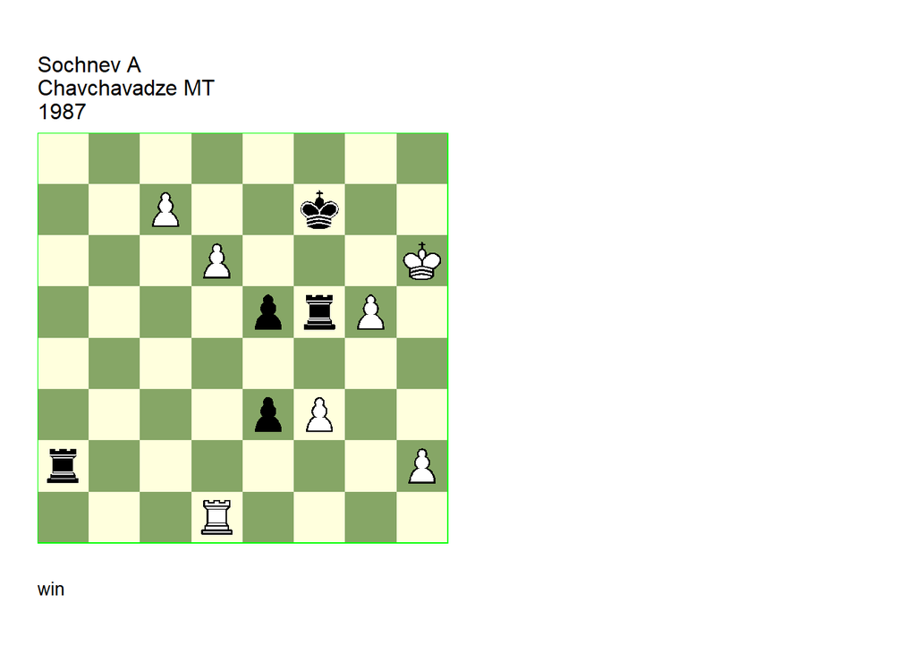

GBR: +0700.52h6f7 U3 U2 FEN: 8/2P2k2/3P3K/4prP1/8/4pP2/r6P/3R4 w - - 0 1

(EG#07736). U3: (EG=119 1/1996). U2: Neuenschwander=B beatochess 19/07/2025. **1. h4 Ra8 2. g6+ Kf6 3. g7 Kf7 4. Rg1 Rf6+ 5. Kh5** (5. Kg5? Rg8) (5. Kh7? Rf5) (5. Kh7! Rf5 6. Rg5! **cook** **BN** ) **5… Rf5+ 6. Kg4 Rf4+** (6… Ke6! **cook** 7. h5 (7. d7 Rf4+ 8. Kh5 Kxd7 9. g8=Q Rxg8 10. Rxg8 Kxc7) (7. Rc1 Rf7 8. c8=Q+ Rxc8 9. Rxc8 Rxg7+) 7… Ra4+ 8. Kg3 Rg5+ 9. Kh3 Rxh5+ 10. Kg2 Rg5+ 11. Kh3 (11. Kf1? Rxg1+ 12. Kxg1 Ra8) ) **7. Kh3 Rxf3+ 8. Kg4** (8. Rg3? e2 9. Rxf3+ Kxg7 10. Re3 Ra3 11. Rxa3 e1=Q 12. c8=Q Qf1+ 13. Kg3 Qg1+) **8… Rf4+ 9. Kh5 Rf5+ 10. Kh6 Rf6+ 11. Kh7 Rf5 12. Rf1 Rxf1 13. d7 Rf5 14. d8=N+ Rxd8 15. cxd8=N+ Kf6 16. g8=N# 1-0**.

### Nadareishvili =0118.03h8h1 (1987). Correction

Date: July 18, 2025

File: Nadareishvili1987a.pgn

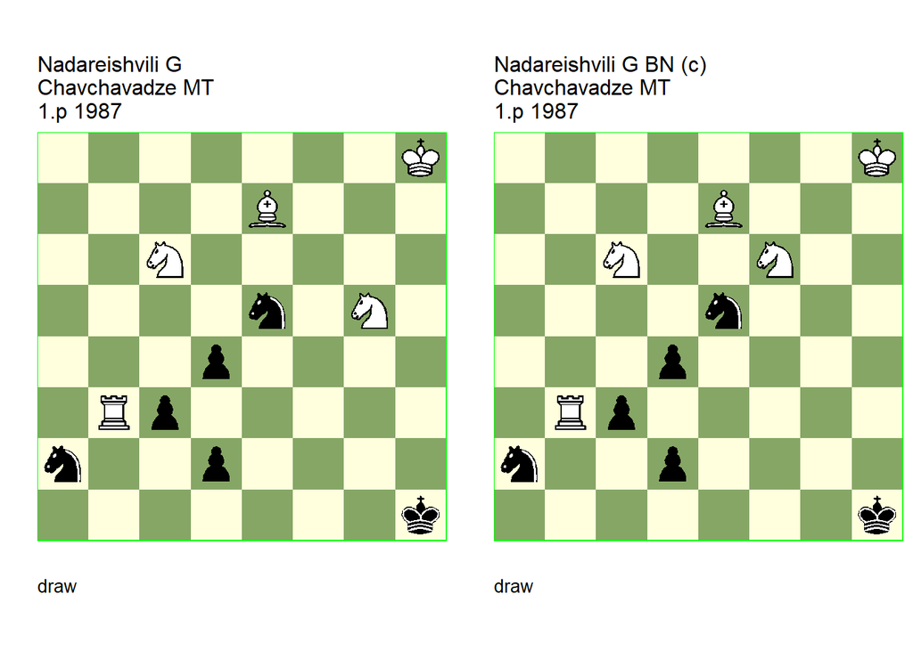

GBR: =0118.03h8h1 U1 FEN: 7K/4B3/2N5/4n1N1/3p4/1Rp5/n2p4/7k w - - 0 1

9/20.p USSR overall champ XVIII 1985-1986 Bulletin Central Chess Club USSR=19(461) Bulletin Central Chess Club USSR/7 1989 (EG#07735). U1: Van, der, Heijden=H HHdbVI 4-11-2018. **1. Ne4!** (1. Rb1+ Nc1 2. Ne4 (2. Nxe5! **cook** HH 2… d1=Q 3. Ngf3 c2 4. Rb6!) 2… Nd3) **1… d1=Q!** (1… c2 2. Nxd2 c1=Q 3. Rb1) **2. Nf2+ Kg1!** (2… Kg2 3. Nxd1 c2 4. Rb2) **3. Nxd1 c2 4. Nc3! Nxc3** (4… dxc3 5. Nd4! Ng6+ 6. Kh7 Nxe7 7. Nxc2) **5. Bg5!** (5. Rxc3? dxc3 6. Nd4 Ng6+ (6… c1=Q 7. Ne2+ Kf2 (7… Kf1 8. Nxc1 Ng6+ 9. Kg7 Nxe7 10. Kf6 Nc6 11. Ke6 Ke1 12. Kd5 Na7 13. Kc4 c2 14. Kb3) 8. Nxc1 Ng6+ 9. Kg7 Nxe7 10. Na2 c2 11. Nb4) 7. Kg7 c1=Q 8. Ne2+ Kf1 9. Nxc1 Nxe7 10. Kf6 Nc6 11. Ke6 c2 12. Kd5 Na7 13. Kc4 Ke1 14. Kd3 (14. Kb3 Kd2 15. Kb2 Nb5 16. Nb3+ Kd1 17. Nc1 Nc3 18. Nb3 (18. Nd3 Kd2) 18… Ne2) 14… Kd1 15. Na2 Nc6 16. Kc3 (16. Nc3+ Kc1) 16… Ne7 17. Kd3 Nd5 18. Kc4 Nf4 19. Kc3 Ne2+ 20. Kb2 Kd2) **5… Nf7+ 6. Kg8! Nxg5 7. Nxd4 c1=Q 8. Rxc3! Qd2** (8… Qxc3 9. Ne2+) (8… Qf1 9. Rc1 Qxc1 10. Ne2+) **9. Rc1+! Kf2** (9… Qxc1 10. Ne2+) **10. Rc2 1/2-1/2**.

GBR: =0118.03h8h1 (c) FEN: 7K/4B3/2N2N2/4n3/3p4/1Rp5/n2p4/7k w - - 0 1

9/20.p USSR overall champ XVIII 1985-1986 Bulletin Central Chess Club USSR=19(461) Bulletin Central Chess Club USSR/7 1989 (EG#07735). Correction: Neuenschwander=B beatochess 18/07/2025. **1. Ne4!** (1. Rb1+? Nc1 2. Ne4 (2. Nxe5 c2 (2… d1=Q 3. Ba3) ) 2… Nd3) **1… d1=Q!** (1… c2 2. Nxd2 c1=Q 3. Rb1) **2. Nf2+ Kg1!** (2… Kg2 3. Nxd1 c2 4. Rb2) **3. Nxd1 c2 4. Nc3! Nxc3** ( 4… dxc3 5. Nd4! Ng6+ 6. Kh7 Nxe7 7. Nxc2) **5. Bg5!** (5. Rxc3? dxc3 6. Nd4 Ng6+ (6… c1=Q 7. Ne2+ Kf2 (7… Kf1 8. Nxc1 Ng6+ 9. Kg7 Nxe7 10. Kf6 Nc6 11. Ke6 Ke1 12. Kd5 Na7 13. Kc4 c2 14. Kb3) 8. Nxc1 Ng6+ 9. Kg7 Nxe7 10. Na2 c2 11. Nb4) 7. Kg7 c1=Q 8. Ne2+ Kf1 9. Nxc1 Nxe7 10. Kf6 Nc6 11. Ke6 c2 12. Kd5 Na7 13. Kc4 Ke1 14. Kd3 (14. Kb3 Kd2 15. Kb2 Nb5 16. Nb3+ Kd1 17. Nc1 Nc3 18. Nb3 ( 18. Nd3 Kd2) 18… Ne2) 14… Kd1 15. Na2 Nc6 16. Kc3 (16. Nc3+ Kc1) 16… Ne7 17. Kd3 Nd5 18. Kc4 Nf4 19. Kc3 Ne2+ 20. Kb2 Kd2) **5… Nf7+ 6. Kg8! Nxg5 7. Nxd4 c1=Q 8. Rxc3! Qd2** (8… Qxc3 9. Ne2+) (8… Qf1 9. Rc1 Qxc1 10. Ne2+) **9. Rc1+! Kf2** (9… Qxc1 10. Ne2+) **10. Rc2 1/2-1/2**.

### Mugnos & Carlsson +4031.13a1g4 (1981). Cooks?

Date: July 18, 2025

File: Mugnos1981a.pgn

A rather mysterious study. White has a large advantage after **5. a5**: how does Black defend? And in the mainline, Black seems to be okay after **13… Kf3**.

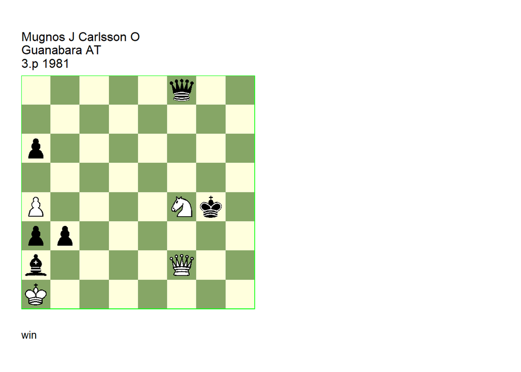

GBR: +4031.13a1g4 U2,U3 FEN: 5q2/8/p7/8/P4Nk1/pp6/b4Q2/K7 w - - 0 1

(EG#07689). U2, U3: Neuenschwander=B beatochess 18/07/2025.. **1. Qe2+** (1. Qg2+? Kf5 2. Qh3+ Kf6 3. Qe6+ Kg5 4. Qe5+ Qf5 5. Ne6+ Kg4 6. Qxf5+ Kxf5 7. Nc7 Ke4 8. Nxa6 Kd4) **1… Kf5 2. Qd3+ Kf6 3. Qxa6+ Kf5 4. Qd3+ Kf6 5. Qg6+** (5. a5? Qb8 6. Qe4 (6. Nd5+ Ke6 7. Qe4+ Kd7 8. Qe7+ Kc6 9. Nb4+ Kb5 10. Qf6 Qa7) 6… b2+ 7. Kxa2 b1=Q+ 8. Qxb1 Qxf4) (5. a5! **cook**? **BN** ) **5… Ke5 6. Qg5+ Ke4 7. Qg2+ Kf5 8. Qh3+ Kf6 9. Qe6+ Kg5** (9… Kg7 10. Nh5+ Kh7 11. Nf6+ Kg7 12. Qg8+ Qxg8 13. Nxg8 Kxg8 14. a5) **10. Qe5+ Kg4 11. a5 Qa8** (11… b2+ 12. Kxa2 Qc8 13. Qe6+) (11… Bb1 12. Kxb1 a2+ 13. Ka1 Qa3 14. Nd3) (11… Qd8 12. Nd5 Qc8 13. Ne3+ Kh4 14. Qf4+ Kh3 15. Qf5+ Qxf5 16. Nxf5 Kg4 17. a6) **12. Nd5 Qa6** (12… Qb7 13. Ne3+ Kh3 (13… Kf3 14. Qd5+ Qxd5 15. Nxd5 Ke4 16. a6 Kd3 17. a7 Kc2 18. Nc3) 14. Qf5+ Kg3 15. Nf1+ Kg2 16. Qd5+ Qxd5 17. Ne3+ Kf3 18. Nxd5 Ke4 19. Nc7 Kd3 20. Nb5 Kc4 21. a6) (12… Qc6 13. Ne3+ Kh3 14. Qf5+ Kh2 15. Qf4+ Kh3 16. Qg4+ Kh2 17. Qg2+) (12… Bb1 13. Nf6+ Kh4 14. Qh5+ Kg3 15. Kxb1 Qc6 16. Qe5+ Kh3 17. Qe3+ Kh2 18. Qd2+ Kg1 19. Qc1+) (12… Kf3 13. Qe3+ Kg4 14. Qe6+ Kg3 15. Qd6+ Kf2 16. a6 Qg8 17. Qc5+ Ke1 18. a7 Qa8 19. Nc3 Kd2 20. Qd5+ Qxd5 21. Nxd5 Kc2 22. Nc3) **13. Qg7+ Kh3** (13… Kf3! **cook**? **BN** ) **14. Nf4+ Kh4 15. Qe7+ Kg3 16. Qe3+ Kh4 17. Qh3+ Kg5 18. Qg3+ Kf5 19. Qg6+ Qxg6 20. Nxg6 Ke4 21. Ne5 Kd4 22. a6 Kc3 23. Nc4 1-0**.

### Ossadnik =0030.56g1b7 (1977). Cook, correction

Date: July 17, 2025

File: Ossadnik1977a.pgn

**3… Bc2!** cooks the study.

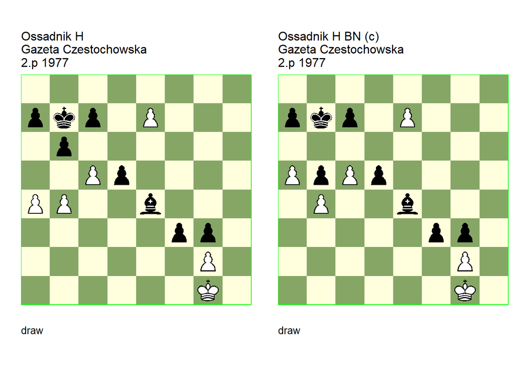

GBR: =0030.56g1b7 U3 FEN: 8/pkp1P3/1p6/2Pp4/PP2b3/5pp1/6P1/6K1 w - - 0 1

U3: Neuenschwander=B beatochess 17/07/2025. **1. c6+ Ka6 2. e8=R!** (2. e8=Q? f2+ 3. Kf1 Bd3+ 4. Qe2 Bc4 5. b5+ Ka5) **2… f2+ 3. Kf1 Bd3+** (3… Bc2! **cook** **BN** 4. Re3 d4 5. Rxg3 d3) **4. Re2 Bxe2+** (4… Bc4 5. b5+ Ka5) **5. Kxe2 d4 6. Kf1 d3 7. b5+ Ka5 1/2-1/2**.

GBR: =0030.56g1b7 (c) FEN: 8/pkp1P3/8/PpPp4/1P2b3/5pp1/6P1/6K1 w - - 0 1

correction: Neuenschwander=B beatochess 18/07/2025. **1. c6+ Ka6 2. e8=R!** (2. e8=Q? f2+ 3. Kf1 Bd3+ 4. Qe2 Bc4) **2… f2+ 3. Kf1 Bd3+ 4. Re2 Bxe2+ 5. Kxe2 d4 6. Kf1 d3 1/2-1/2**.

### Dobrescu +3200.23h3h5 (1988). Cook

Date: July 8, 2025

File: Dobrescu1988a.pgn

**8. Rxg5+ Kxg5 9. Rb1 Kf4 10. Ra1!** wins in the **5… Qe5** mainline.

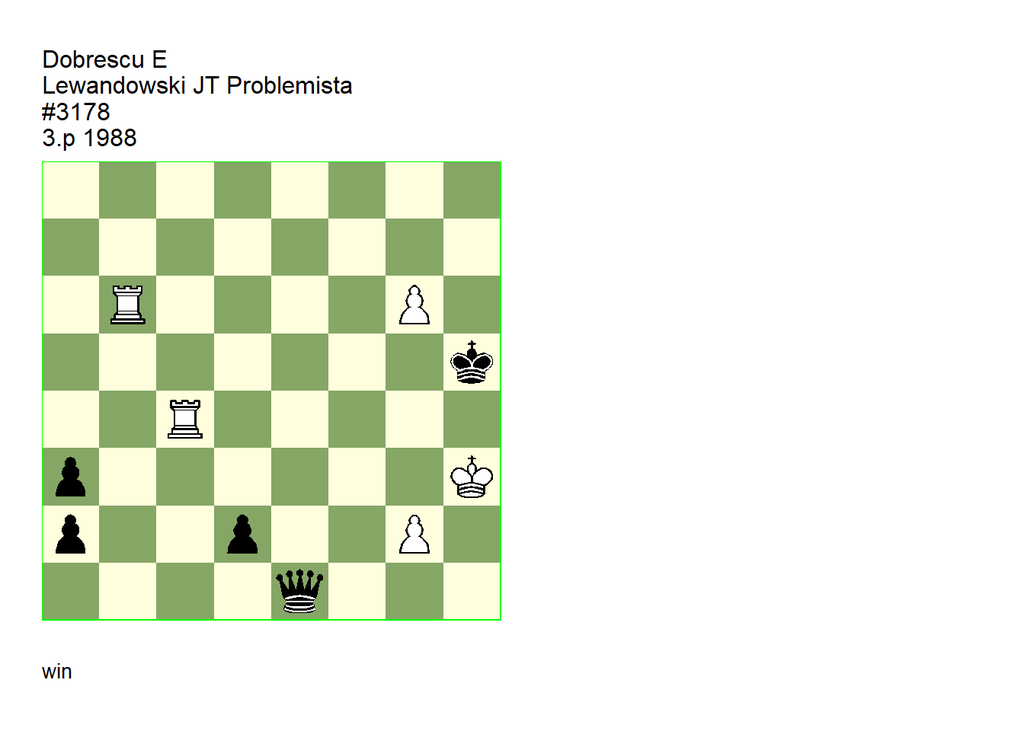

GBR: +3200.23h3h5 U2 FEN: 8/8/1R4P1/7k/2R5/p6K/p2p2P1/4q3 w - - 0 1

Problemista=246-248 Problemista/10-12 (EG#07525). U2: Neuenschwander=B beatochess 08/07/2025. **1. g7** (1. Rc5+? Kh6 2. g7+ Kh7 3. g8=Q+ Kxg8 4. Rc8+ Kf7 5. Rb7+ Qe7) **1… Qh1+** (1… Qe3+ 2. g3) (1… a1=Q 2. g4+) **2. Kg3 Qe1+ 3. Kh2 Qg1+** (3… Qh1+ 4. Kxh1) **4. Kxg1 a1=Q+** (4… d1=Q+ 5. Kh2 Qd5 6. g4+ Kh4 7. Rh6+ Kg5 8. Rh5+ Kf6 9. Rxd5) **5. Kh2 Qxg7** (5… Qe5+ **main** 6. Kh3 Qxg7 ( 6… Qf5+ 7. g4+ Qxg4+ 8. Rxg4 d1=Q 9. Rh4+) 7. Rc5+ Qg5 8. g4# (8. Rxg5+? Kxg5 9. Rb1 Kf4 10. g4 (10. Ra1! **cook** **BN** ) 10… Ke3 11. g5 Ke2 12. g6 a2 ) ) **6. Rc5+** (6. Rb5+? Qg5) **6… Kh4** (6… Qg5 7. Rxg5+ Kxg5 8. Rb1 Kf4 9. Kg1 Ke3 10. Kf1 Kd3 11. Ra1 Kc2 12. Ke2) **7. Rb4+ Qg4 8. g3# 1-0**.

### Maksimovskikh & Shupletsov =0413.33b3a6 (1984). Cook, dual

Date: July 8, 2025

File: Maksimovskikh1984b.pgn

The intermezzo **5… Rf7** should be dropped because **6. Bxf7** draws. There still remains the dual **9. Ra5+** (change of move order) as a flaw.

[figure not shown]

GBR: =0413.33b3a6 U2 FEN: B7/p7/k7/8/6PP/1KPp4/1Rp1r3/4n3 w - - 0 1

The Problemist=4 The Problemist/7 1985 (EG#07520). U2: Neuenschwander=B beatochess 08/07/2025. **1. Ka4 Re7 2. Bd5 Rc7 3. Rb5 Rd7** (3… c1=Q 4. Ra5+ Kb6 5. Rb5+ Ka6 6. Ra5+) **4. Bc4 Rc7 5. Bd5 Rf7 6. Rb4** (6. Bxf7! **cook** **BN** 6… c1=Q 7. Bc4 Qa1+ 8. Kb3 Qb1+ 9. Ka4 Qa1+ 10. Kb3) **6… Rc7 7. Rb5 Rd7 8. Bc4 Rd4 9. cxd4** (9. Ra5+! **dual** **BN** 9… Kb6 10. Rb5+ Kc6 11. cxd4) **9… c1=Q 10. Ra5+** (10. Rc5+? Qxc4+ 11. Rxc4 d2) **10… Kb6 11. Rb5+ Kc7 12. Rc5+ Kd6 13. Rd5+ Ke6 14. Re5+ Kf6 15. Rf5+ Kg6 16. Rg5+ Kh6 17. Rh5+ 1/2-1/2**.

### Gurgenidze +0800.11a2e3 (1988). Cook, correction

Date: July 8, 2025

File: Gurgenidze1988a.pgn

**1… Kf4!** seems to draw. The study is correct with the king on e2.

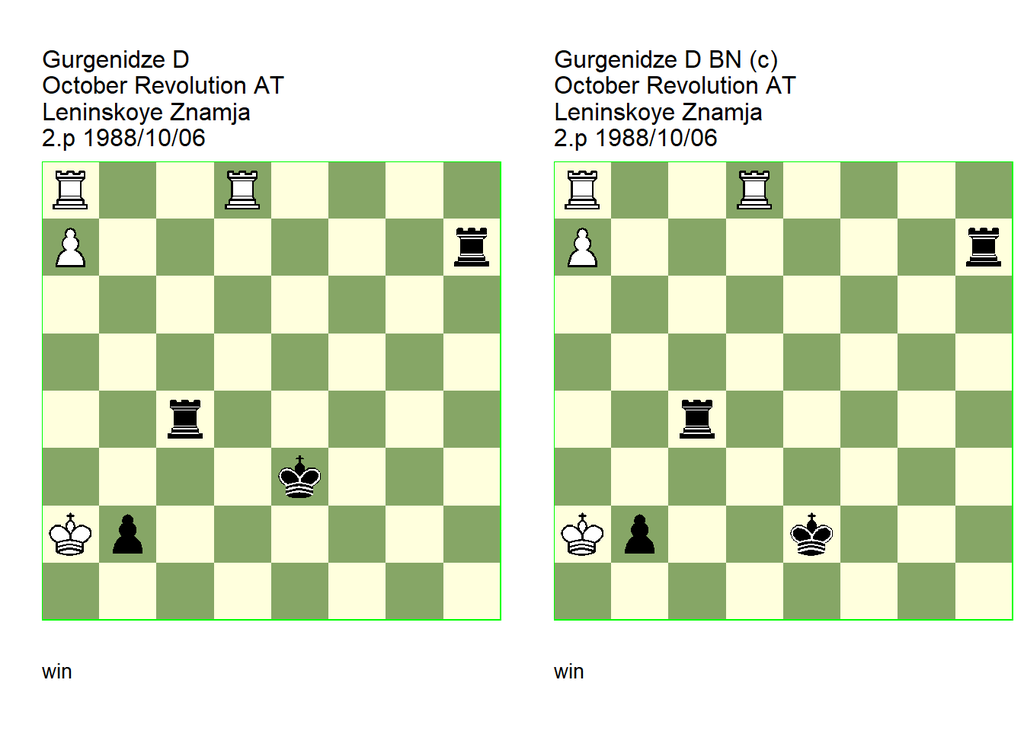

GBR: +0800.11a2e3 U3 FEN: R2R4/P6r/8/8/2r5/4k3/Kp6/8 w - - 0 1

(EG#07501). Neuenschwander=B beatochess 08/07/2025. **1. Re8+ Kf2!** (1… Kf4! **cook** **BN** 2. Re4+ Rxe4 3. Rf8+ Ke5 4. Re8+ (4. a8=Q b1=Q+ 5. Kxb1 Rh1+ 6. Kc2 Rh2+ 7. Kc3 Rh3+) 4… Kf5 5. a8=Q b1=R 6. Kxb1 Rh1+ 7. Kc2 Rh2+) **2. Re2+!** (2. Rf8+? Kg2 3. Rf2+ Kh3) **2… Kxe2 3. Re8+ Kd1! 4. a8=Q b1=Q+ 5. Kxb1 Rb7+! 6. Ka2!** (6. Qxb7? Rb4+ 7. Qxb4) **6… Rc2+ 7. Ka3 Rc3+ 8. Ka4 Rcc7! 9. Rd8+!** (9. Qd8+? Rd7 10. Qc8 Rbc7!) **9… Kc2 10. Rc8! 1-0**.

GBR: +0800.11a2e2 (c) FEN: R2R4/P6r/8/8/2r5/8/Kp2k3/8 w - - 0 1

correction: Neuenschwander=B beatochess 08/07/2025. **1. Re8+ Kf2 2. Re2+!** ( 2. Rf8+? Kg2 3. Rf2+ Kh3) **2… Kxe2 3. Re8+ Kd1! 4. a8=Q b1=Q+ 5. Kxb1 Rb7+! 6. Ka2!** (6. Qxb7? Rb4+ 7. Qxb4) **6… Rc2+ 7. Ka3 Rc3+ 8. Ka4 Rcc7! 9. Rd8+!** (9. Qd8+? Rd7 10. Qc8 Rbc7!) **9… Kc2 10. Rc8! 1-0**.

### Micu =0341.10d5g6 (1987). Dual

Date: July 7, 2025

File: Micu1987a.pgn

**11. Nf7!** is a dual.

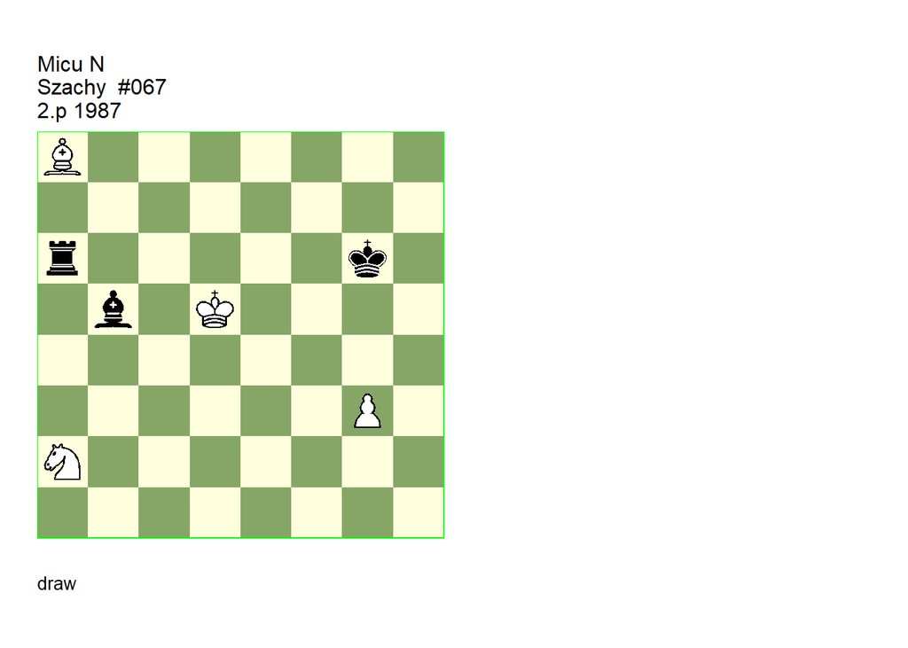

GBR: =0341.10d5g6 (U2) FEN: B7/8/r5k1/1b1K4/8/6P1/N7/8 w - - 0 1

Szachy=8(485) Szachy/8 (EG#07488). (U2): Neuenschwander=B beatochess 07/07/2025. **1. Nc3 Be8!** (1… Bf1 2. Bb7 Bg2+ 3. Ne4 Rb6 4. Ba8 Rb8 5. Bc6 Rc8 6. Kd6) (1… Bd7 2. Bb7 Rb6 3. Ba8 Rb8 4. Kd6!) **2. Bb7 Rb6** (2… Ra7 3. Bc6! Ra5+ 4. Bb5) **3. Bc8!** (3. Ba8? Rb8 4. Bc6 Bxc6+ 5. Kxc6 Rc8+) **3… Rc6 4. Bf5+! Kxf5 5. Ne4!** (5. Nb5? Kf6!) **5… Bd7 6. Nc5 Rc7 7. Kd6 Rc6+ 8. Kd5 Be8 9. Ne4 Kg4 10. Nd6 Bd7 11. Nc4!** (11. Nf7! **dual** **BN** ) **11… Rc7 12. Ne5+ Kxg3 13. Kd6 1/2-1/2**.

### Marwitz +3400.61f2f8 (1987). Cook

Date: June 30, 2025

File: Marwitz1987a.pgn

There is second cook. White cannot win after **4… Kxg7**.

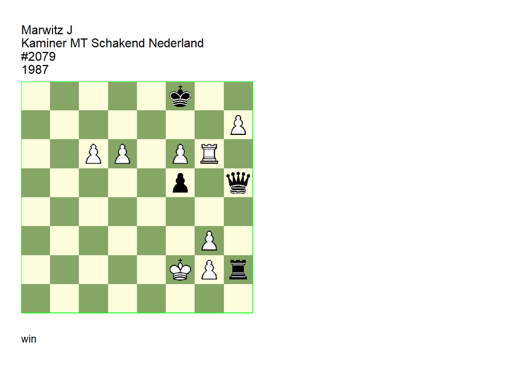

GBR: +3400.61f2f8 U2 U3 FEN: 5k2/7P/2PP1PR1/5p1q/8/6P1/5KPr/8 w - - 0 1

Schakend Nederland/1 (EG#07475). U2: Schakend Nederland/5 1989 U2: Van, der, Heijden=H HHdbIV#55800 26-5-2006. U3: Neuenschwander=B beatochess 03/07/2025. **1. h8=Q+** (1. Rg8+? Kf7 2. h8=Q Rxg2+) **1… Qxh8 2. d7!** (2. c7? Kf7 3. Rg7+ Ke6 4. d7 Qa8 5. Re7+ Kxf6) **2… Kf7 3. Rg7+ Kxf6** (3… Ke6 4. Re7+ Kd6 (4… Kxf6 5. Re8!) 5. Re8 Qxf6 6. d8=Q+ Qxd8 7. Rxd8+ Kxc6 8. Kf3) **4. c7 Qxg7** (4… Qh3 5. d8=Q+ Kxg7 6. Qd7+ Kg6 7. Qc6+ Kg7 8. c8=Q) (4… Rxg2+ 5. Kxg2 Qa8+ 6. Kh2 Qa2+ 7. Kh3) (4… Kxg7! **cook** **BN** 5. d8=Q (5. c8=Q Kf7 6. d8=Q Qb2+ 7. Ke3 Qe5+ 8. Kd3 Qxg3+ 9. Kc4 Qh4+) 5… Kg6 6. c8=Q Qb2+ 7. Ke3 Qe5+ 8. Kd3 Qxg3+ 9. Kc4 Rh4+) **5. c8=Q** (5. d8=Q+ Ke5! 6. Qe8+ (6. Qd2! **cook** ) (6. c8=Q Qa7+ 7. Kf3 Qa3+) (6. Qb8! **cook** HH ) 6… Kd6 7. c8=Q Qd4+ 8. Qe3 (8. Kf3 Qg4+) 8… Rxg2+ 9. Kxg2 Qxe3 10. Qxf5 Ke7 11. Kh3 Qd4) **5… Rh8** (5… Ke5 6. Qc3+) (5… Kf7 6. Qe8+) (5… Kg6 6. Qc6+ Kh7 7. d8=Q Qb2+ 8. Ke3 Qe5+ 9. Kf3) **6. Qe8! Rxe8 7. dxe8=N+! Kf7 8. Nxg7 Kxg7** eg **9. Kf3 Kg6 10. Kf4 Kf6 11. g4 1-0**.

### Grondijs =0416.11d6h8 (1987). Cook

Date: June 30, 2025

File: Grondijs1987a.pgn

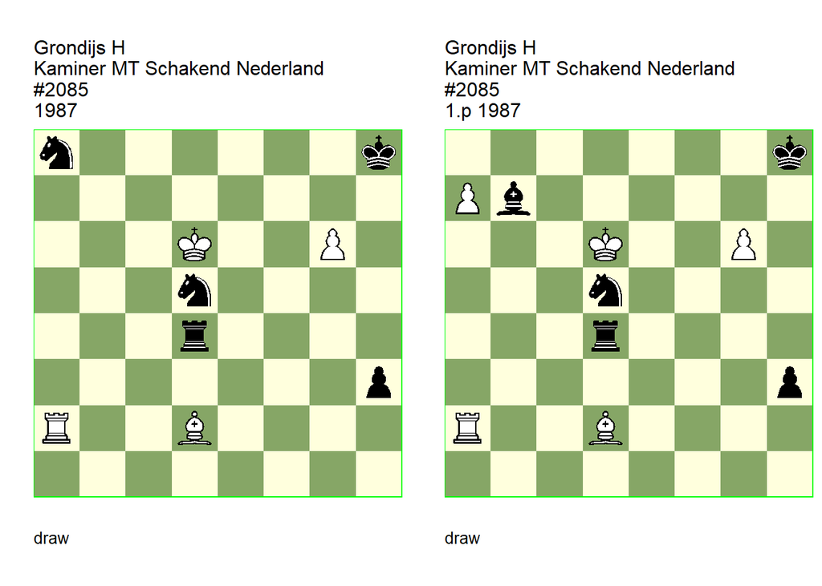

GBR: =0416.11d6h8 U2 FEN: n6k/8/3K2P1/3n4/3r4/7p/R2B4/8 w - - 0 1

Schakend Nederland/4. U2: Schakend Nederland/5 1989. **1. Ke5** (1. Rxa8+? Kg7 2. Bh6+ Kxg6 3. Rg8+ Kh7 4. Rg1 Kxh6) (1. Kc5? h2 2. Bh6 (2. Bc3 h1=Q 3. Bxd4+ Nf6) 2… Rc4+ 3. Kd6 Rc6+ 4. Ke5 Nf6 5. Rxh2 (5. Rxa8+ Ng8 6. Ra7 Rxg6) 5… Ng4+ 6. Kd5 Rxg6) **1… h2 2. Bh6 Re4+ 3. Kd6** (3. Kxd5? h1=Q 4. Rxa8+ Re8+) **3… Re6+ 4. Kc5** (4. Kxe6! **cook** 4… Nac7+ 5. Kf7) **4… Rc6+ 5. Kd4 Rc4+ 6. Ke5 Nf6 7. Rxa8+** (7. Rxh2? Ng4+ 8. Kd5 Nb6+) **7… Ng8 8. Ra7 Re4+ 9. Kd6 Nxh6 10. Rh7+ Kg8 11. Rxh6 Re2 12. Rh7 1/2-1/2**.

GBR: =0443.21d6h8 (c) U3 FEN: 7k/Pb6/3K2P1/3n4/3r4/7p/R2B4/8 w - - 0 1

Schakend Nederland/4 (EG#07473). correction: Van, Reek=J Schakend Nederland/5 1989. U3: Neuenschwander=B beatochess 03/07/2025. **1. Ke5** (1. a8=Q+? Bxa8 2. Ke5 Re4+ 3. Kxe4 Nc3+ 4. Kf4 Nxa2 5. Kg3 Bg2) **1… h2** (1… Re4+ 2. Kxe4 Nc3+ 3. Kf4 Nxa2 4. Kg3 Bg2 5. a8=Q+) **2. a8=Q+** (2. Bh6? Re4+ 3. Kd6 Re6+ 4. Kc5 Rc6+ 5. Kd4 h1=Q 6. a8=Q+ Rc8 7. Qxb7 Qh4+) **2… Bxa8 3. Bh6 Re4+ 4. Kd6 Re6+ 5. Kc5 Rc6+** (5… Rxg6! **cook** **BN** 6. Rxh2 Ra6 -+ DTZ107 ) **6. Kd4 Rc4+ 7. Ke5 Nf6 8. Rxa8+ Ng8 9. Ra7 Re4+ 10. Kd6 Nxh6 11. Rh7+ Kg8 12. Rxh6 Re2 13. Rh7 1/2-1/2**.

### Haring +0324.14c8c6 (1988). Cook

Date: June 30, 2025

File: Haring1988a.pgn

There is a flaw in the second mainline: instead of the immediate mate, **6. Bd7** seems winning.

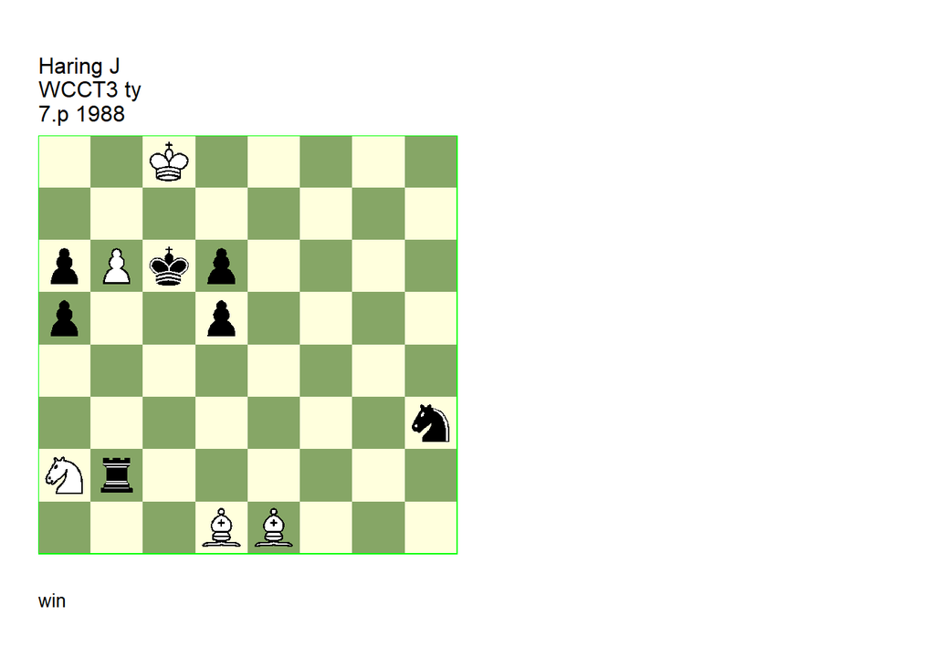

GBR: +0324.14c8c6 TT U2 FEN: 2K5/8/pPkp4/p2p4/8/7n/Nr6/3BB3 w - - 0 1

WCCT3 ty 1984-1988 (EG#07444). U2: Neuenschwander=B beatochess 02/07/2025. **1. Ba4+ Kxb6 2. Bc3 Rb5 3. Bd4+ Kc6** (3… Rc5+ **main** 4. Kb8 Nf4 5. Nc3 Ne6 6. Nxd5# (6. Bd7 **cook** **BN** 6… a4 7. Nxd5+ Ka5 8. Bxe6 +/-) ) **4. Nc1 Nf4 5. Nb3 Ne6 6. Nxa5# 1-0**.

## Wotawa

### Wotawa +0400.12a4a1 (1952). Correction

Date: September 7, 2025

File: Wotawa1952a.pgn

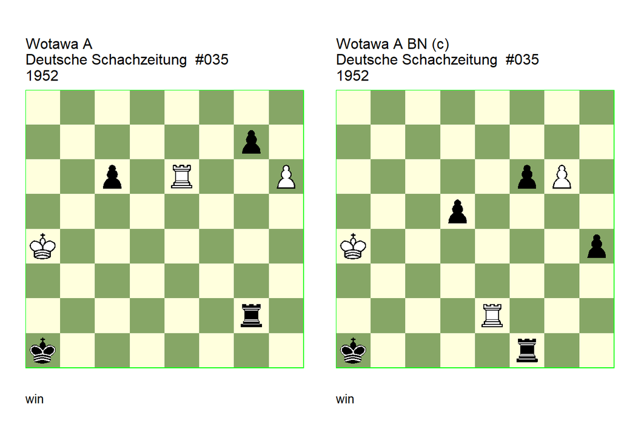

GBR: +0400.12a4a1 U2 U3 FEN: 8/6p1/2p1R2P/8/K7/8/6r1/k7 w - - 0 1

Deutsche Schachzeitung=5 Deutsche Schachzeitung/2. U2= U3: Cheron=A Journal de Geneve=207 7-9-1965 U3: Konoval=Y HHdbV#58068 19-3-2011. **1. h7** (1. Re1+? Kb2 2. h7 Rg4+ (2… Rh2? 3. Re2+) ) (1. Kb3? Rg3+ 2. Kc4 gxh6) **1… Rg4+** ( 1… Rh2 2. Re1+ Kb2 3. Re2+ Rxe2! **cook** YK 4. h8=Q Re4+!) (1… Ra2+ 2. Kb3 Rb2+ 3. Kc3 Rb8 (3… Rh2 4. Re1+ Ka2 5. Re2+) 4. Re7 g5 (4… Rh8 5. Kc2) 5. Ra7+ Kb1 6. Rb7+) **2. Kb3 Rg3+ 3. Kc2 Rh3** (3… Rg2+ 4. Kd3 Rg3+ 5. Re3) **4. Re3!** (4. Rxc6? Rh2+ 5. Kb3 Rb2+ 6. Kc3 Rh2) **4… Rh2+ 5. Kb3 Rb2+** (5… Rh1 6. h8=Q) **6. Ka4** (6. Ka3? Ra2+ 7. Kb3 Rb2+ 8. Kc3 Rb8 9. Rh3 Rh8 10. Kc2 Ka2 11. Rh5 Ka3 12. Kc3 Ka4 13. Kd4 g5 14. Ke5 c5 15. Kf6 c4) (6. Kc3! **cook** AC 6… Rb8 7. Rg3 Rf8 (7… Rh8 8. Rxg7 Kb1 (8… Ka2 9. Rg2+ Ka3 10. Rh2) 9. Rg1+ Ka2 10. Rh1) (7… Ka2 8. Kc4 Rh8 9. Rxg7 Kb2 10. Kc5 Kc3 11. Kxc6 Kd4 12. Kd6) 8. Kb3! (8. Kc4? Rf4+ 9. Kc5 Rh4 10. Rxg7 Rh6!) 8… Rb8+ 9. Kc4 Rf8 (9… Rh8 10. Rxg7) 10. Kc5 Rf5+ 11. Kxc6 Rh5 12. Rxg7) **6… Rb8 7. Ra3+** (7. Rh3! **cook** AC 7… Ra8+ 8. Kb3 Rb8+ 9. Kc2 Rb2+ 10. Kc3) **7… Kb2 8. Rb3+ Rxb3 9. h8=Q Ra3+** eg **10. Kb4 Rb3+ 11. Ka5 Ra3+ 12. Kb6 Rc3 13. Qxg7 c5!** **cook** AC **1-0**.

GBR: +0400.13a4a1 (c) FEN: 8/8/5pP1/3p4/K6p/8/4R3/k4r2 w - - 0 1

correction: Neuenschwander=B beatochess 07/09/2025. **1. g7 Rf4+** (1… Rg1 2. Re1+ Rxe1 3. g8=Q) **2. Kb3 Rf3+ 3. Kc2 Rg3 4. Re3! Rg2+ 5. Kb3 Rb2+ 6. Ka4!** (6. Ka3 Ra2+ loses time ) **6… Rg2 7. Re1+ Kb2 8. Re2+ Rxe2 9. g8=Q h3 10. Qxd5 h2 11. Qf3 Rd2 12. Qxf6+ Kc2 13. Qf3 1-0**.

### Wotawa +0400.31b5a8 (1942). Correction

Date: September 5, 2025

File: Wotawa1942a.pgn

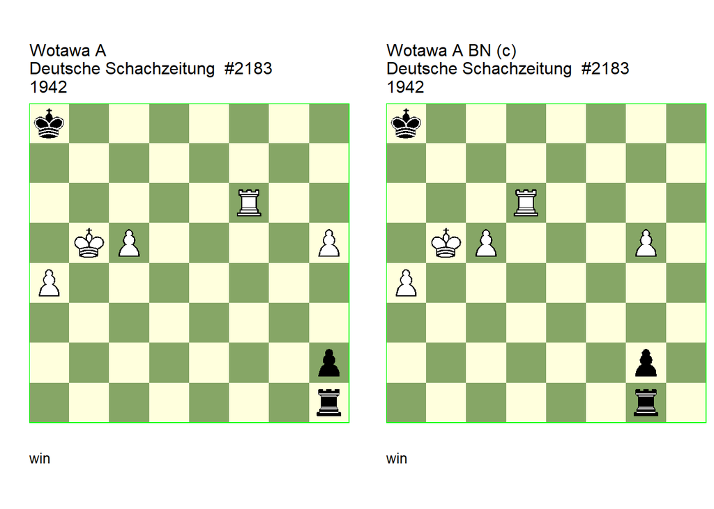

GBR: +0400.31b5a8 U3 FEN: k7/8/5R2/1KP4P/P7/8/7p/7r w - - 0 1

Deutsche Schachzeitung/4. U3: Garcia=M HHdbIV#20783 20-7-2006. **1. Ka6 Rb1!** (1… Kb8 2. Rf2 Kc7 3. h6 Kc6 4. Ka5 (4. a5? Re1 5. Rxh2 Re8 6. Ka7 Re7+) ) **2. Rf8+ Rb8 3. Rf1 h1=Q!** (3… Rh8 4. c6 Kb8 5. Kb6 Kc8 6. a5 Kd8 7. a6 Rxh5 8. a7) (3… Rb4! **cook** MG 4. Rh1 Rh4) **4. Rxh1 Rb1 5. Rh4 Rb4 6. c6 Rxh4 7. c7 Rc4 8. Kb6 Rc1 9. h6 Rb1+ 10. Ka6 Rb6+ 11. Ka5 Ra6+ 12. Kb5 Rb6+ 13. Kc5 Kb7 14. c8=Q+ Kxc8 15. Kxb6 1-0**.

GBR: +0400.31b5a8 (c) FEN: k7/8/3R4/1KP3P1/P7/8/6p1/6r1 w - - 0 1

Correction: Neuenschwander=B beatochess 05/09/2025. **1. Ka6 Rb1 2. Rd8+ Rb8 3. Rd1 g1=Q** (3… Rb4 4. g6 Rxa4+ 5. Kb6 Rb4+ 6. Kc7 Rb7+ 7. Kd8 Rg7 8. c6 Ka7 9. c7) **4. Rxg1 Rb1 5. Rg4 Rb4 6. c6 Rxg4 7. c7 Rc4 8. Kb6 Rc1 9. g6 Rb1+ 10. Ka6 Rb6+ 11. Ka5 Ra6+ 12. Kb5 Rb6+ 13. Kc5 Kb7 14. c8=Q+ Kxc8 15. Kxb6 1-0**.

### Wotawa =0400.12a5a7 (1953). Cook

Date: September 4, 2025

File: Wotawa1953a.pgn

**4. Rb4+!** cooks the study.

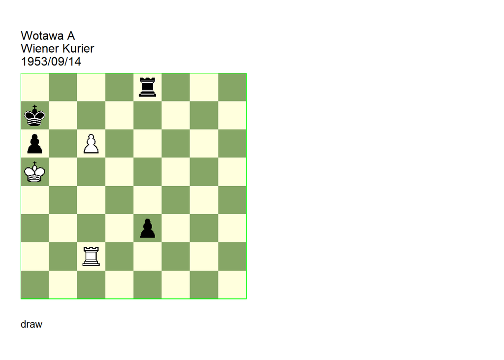

GBR: =0400.12a5a7 U2 FEN: 4r3/k7/p1P5/K7/8/4p3/2R5/8 w - - 0 1

U2: Neuenschwander=B beatochess 04/09/2025. **1. c7!** (1. Re2? Re4! 2. c7 Kb7 3. c8=Q+ Kxc8 4. Kxa6 Kc7 5. Kb5 Kd6) **1… Kb7** (1… e2 2. Rxe2) **2. c8=Q+! Rxc8 3. Rc4!** (3. Re2? Re8 4. Kb4 a5+! 5. Kc3 (5. Kxa5 Kc6 6. Kb4 Kd5 7. Kc3 Ke4) 5… a4 6. Kd3 a3) **3… e2** (3… Rg8 4. Re4 Rg3 5. Re6 Kc7 6. Kb4! (6. Rxa6? Kd7! 7. Kb4 e2! 8. Ra1 Re3) ) (3… Re8 4. Re4! Rxe4) ( 3… Rxc4) (3… Rf8 4. Re4 Rf3 5. Kb4 a5+ (5… Kc6 6. Kc4 a5 7. Kd3) 6. Kc3 Kc6 7. Kd3 Kb5 8. Rxe3) **4. Re4** (4. Rb4+! **cook** **BN** 4… Ka7 5. Re4 Rc2 6. Re7+) **4… Rc2 5. Kb4 a5+ 6. Kb3!** (6. Kxa5? Kc6 7. Kb4 Kd5 8. Re8 Rc4+ 9. Kb3 Re4) **6… Rd2 7. Kc3 Ra2 8. Kb3 1/2-1/2**.